# Flight: 20220121230742dis

01 octubre 2022

### La variable dscrPhase indica la fase del vuelo en cada momento:

- Se calcula en función de la posición de la aeronave en cada momento con respecto al tramo (leg) más cercano, teniendo en cuenta de qué tipo de tramo se trata.
- Hay unos umbrales para decidir la distancia al “turning point” a la que cambiar de fase.
- Esta variable tiene en cuenta si el viraje es “flyby” o “flyover”.

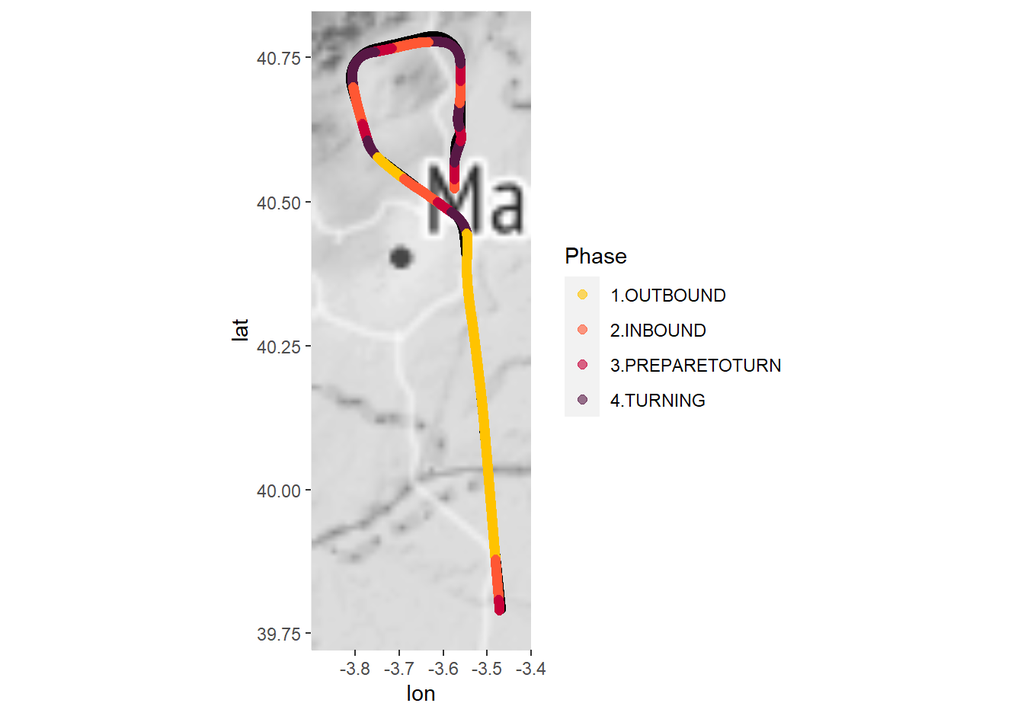

### DIFERENCIAS ENTRE ÁNGULOS:

- ```
            angleCLCrs          anglePBNleg         anglePBNnxtleg
  ```

- angleM angdifHCl angdifHClP(3) angdifHNxP(1)
- angleHDGval angdifSCl angdifSClP(2) angdifSNxP(2)

##### Discarded vars:

1. angdifHNxP is irrelevant, because the heading is not related with the next leg.
2. are not useful “as they are”. That’s why we produce 2 binary vars to describe if the pilot’s HDG setting is focused on the current leg or in the next one: discrSettingNextHdg & discrSettingCurrHdg
3. angdifHClP is “noisy” at the beginning of the turns. So we use only angdifHCl

##### Graph color meanings:

-orange: angdifHCl  
-blue: discrSettingNextHdg (higher) & discrSettingCurrHdg (lower)  
-green: angdifSCl  
-red: PBNdeviation & PBNLegChange (indicates the instant of the leg change)

##### Flight 1 :

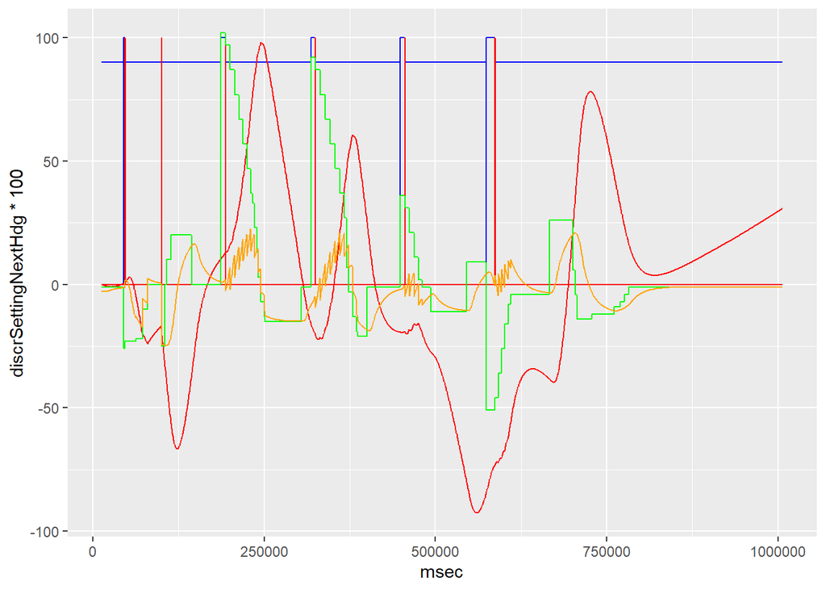

##### Flight 2 :

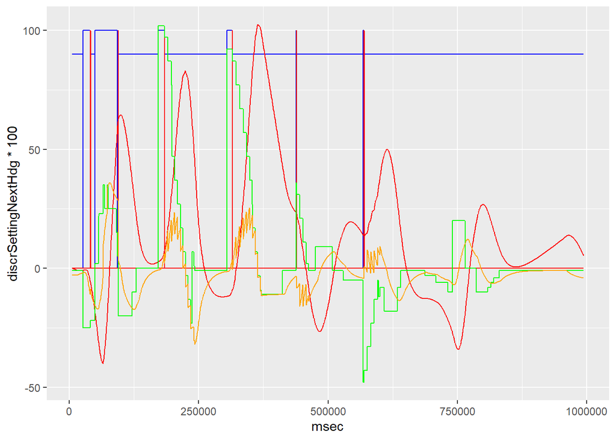

##### Flight 3 :

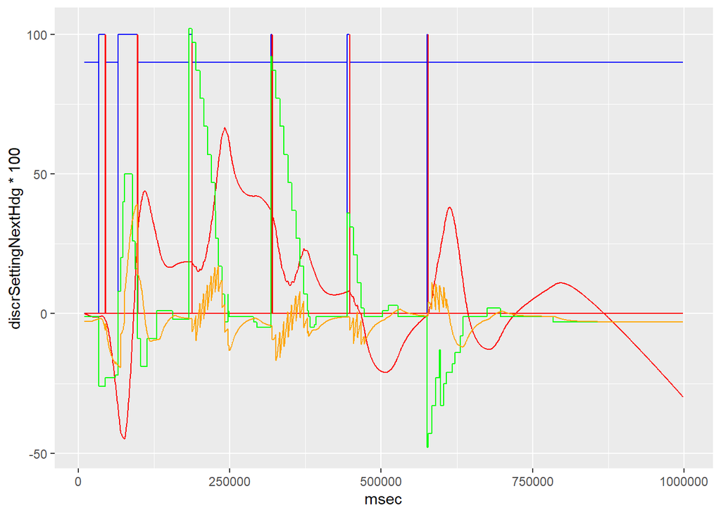

### Esta gráfica muestra las variables descritas:

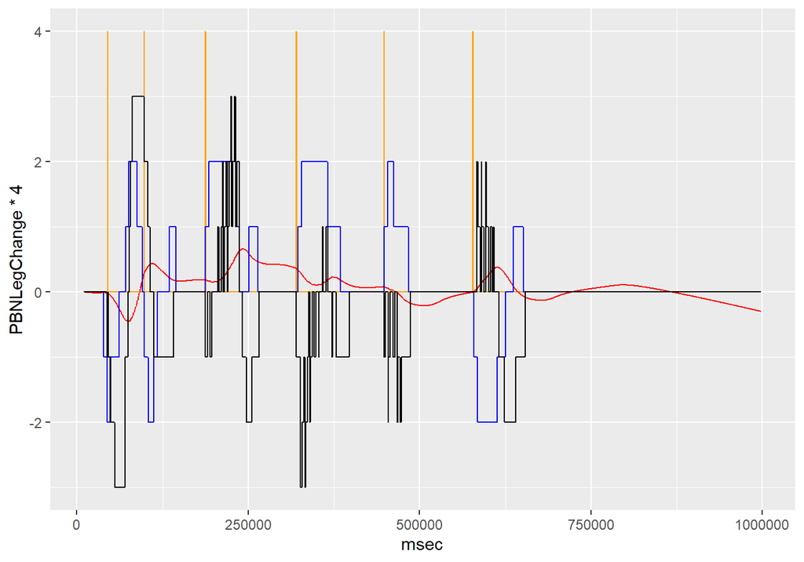

- orange: PBNLegChange  
- red: PBNdeviation  
- blue: dscrBank  
- black: dscrAngleBrM

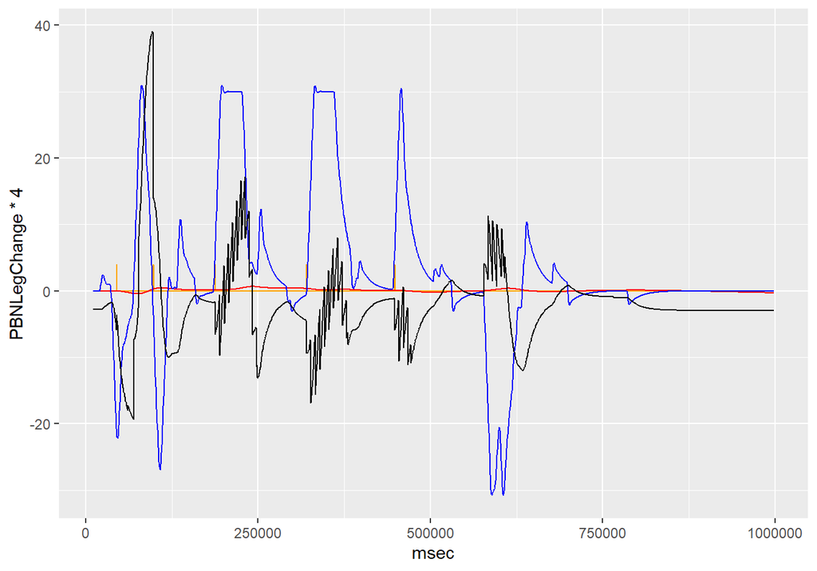

- orange: PBNLegChange  
- red: PBNdeviation  
- blue: bank  
- black: angleBrM

#### Nótese la relación entre PBNdeviation y dscrBank con este ejemplo:

##### Si nos desviamos a la izquierda de la ruta, PBNdeviation será positivo. Para corregir el error habrá que virar hacia la derecha, es decir, hacer que dscrBank sea negativo. El efecto de esta corrección no es inmediato, pero en la gráfica se puede observar cómo se produce. Más adelante se intentarán generar variables que midan cómo de adecuadas son las correcciones que hace el piloto.

##### Pero la interpretación no es sencilla en los tramos de viraje, para verlo claro es mejor fijarse en un tramo recto.

##### Por ejemplo, para el vuelo 20220121230742dis, en torno a msec=75e4 (en mitad del último tramo recto), en el mapa se puede observar que la trayectoria del avión hace una “S”: primero se desvía a la derecha de la ruta y luego, tras una corrección excesiva, se desvía a la izquierda de la ruta, para volver después a centrarse. La vemos en una pequeña oscilación de PBNdeviation (rojo), que se hace más negativa y después se hace positiva (avión a la izquierda de la ruta).

##### El error inicial negativo (avión a la derecha de la ruta) es compensado por el piloto virando a la izquierda (dscrBank>0), pero como vira demasiado, el error enseguida se hace positivo (avión a la izquierda de la ruta), pero el piloto vira a la derecha (dscrBank<0), esta vez con la intensidad adecuada para conseguir mantener el error casi nulo el resto del tramo.

#### Relación entre dscrBank y dscrAngleBrM:

##### Al virar se modifica el rumbo del avión, pero no es el rumbo lo relevante para nosotros ahora, sino la diferencia entre el rumbo y la ruta. Hay que tener en cuenta que durante los tramos de ruta “curvos”, tanto la ruta como el rumbo van variando y es de esperar cierta inestabilidad en el valor de dscrAngleBrM. En este sentido, la variable dscrPhase debería ser relevante para distinguir distintas situaciones.

##### En un tramo de ruta recto, el valor de dscrAngleBrM debería depender solo del rumbo. Por ejemplo, para el vuelo 20220121230742dis, en torno a msec=75e4, en mitad de un tramo recto, se puede observar una correlación clara entre dscrBank (azul) y dscrAngleBrM (negro), que tiene prácticamente la misma forma, pero con un determinado retraso debido a que al virar el rumbo tarda varios segundos en cambiar.

##### Durante el resto del vuelo, la correlación es más difícil de observar, especialmente en los tramos curvos de la ruta, que se dan en torno a los pasos por los “waypoints”, que en la gráfica están representados por las líneas naranjas verticales.

### Discretizaciones del tiempo desde consultas de información:

##### Las siguientes gráficas muestran cómo se han discretizado los chequeos de información. La idea es que si no se producen chequeos, la variable vale 0. Cada ve que se produzca un chequeo, la variable pasa a valer 4 y se resta 1 cuando pasan 3, 20, 60 y 180 segundos sin que se vuelva a producir un chequeo, volviendo en este caso a valer 0.

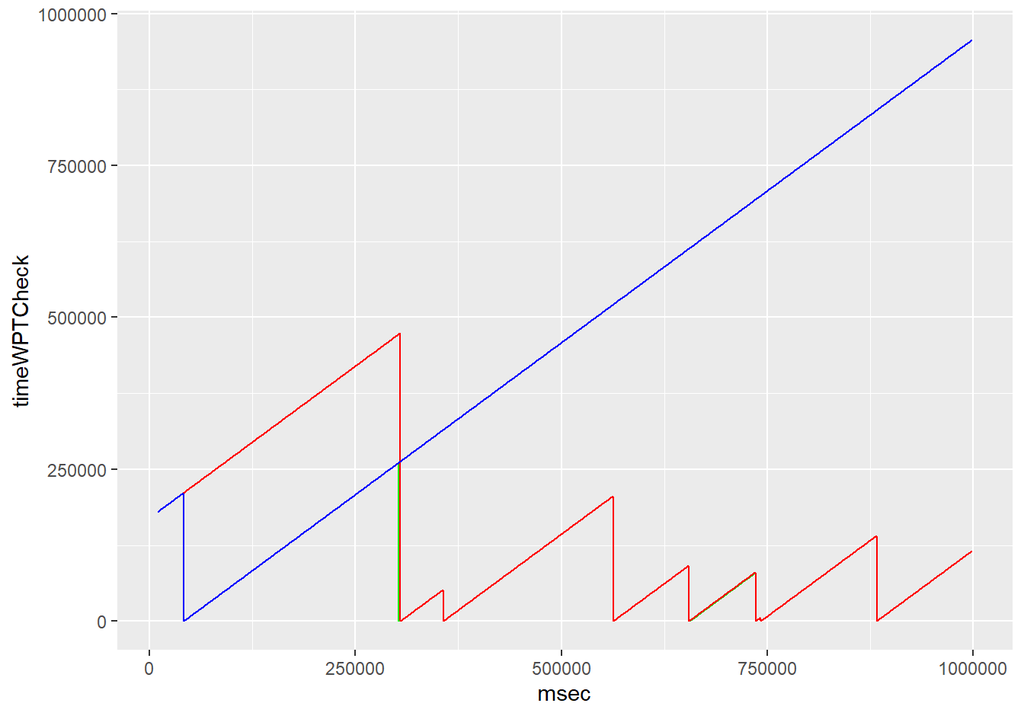

-green: timeWPTCheck  
-red: timeWPTCheckCurrLeg  
-blue: timeWPTCheckNxtLeg

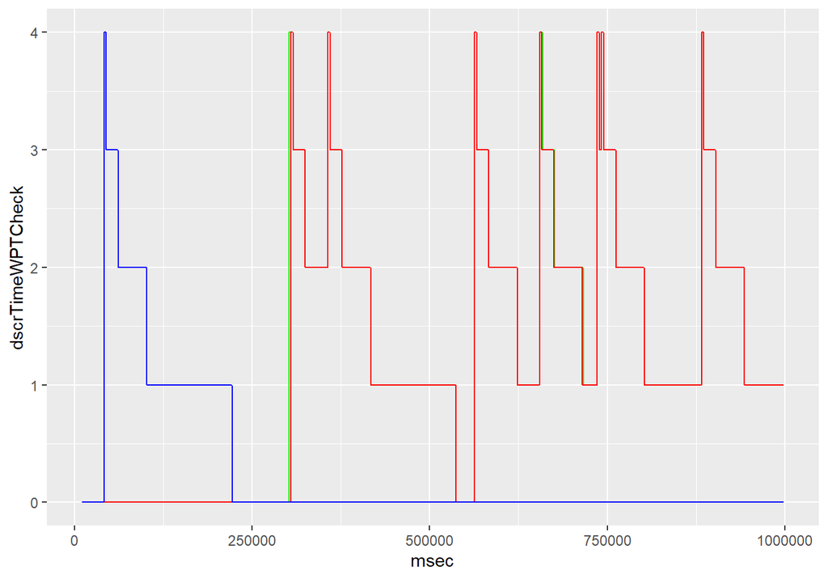

-green: dscrTimeWPTCheck  
-red: dscrTimeWPTCheckCurrLeg  
-blue: dscrTimeWPTCheckNxtLeg

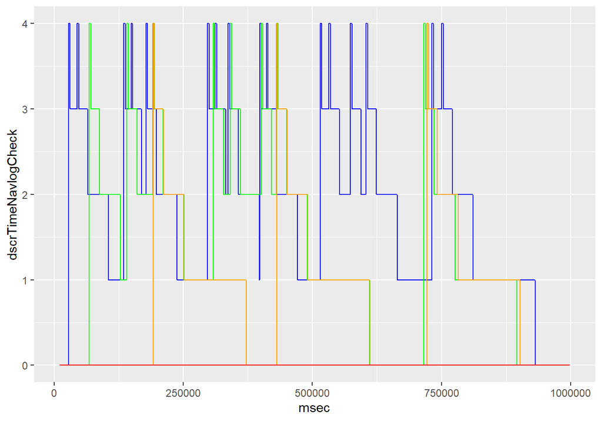

-blue: dscrTimeNavlogCheck  
-green: dscrTimeMapCheck  
-orange: dscrTimeTrackCheck  
-red: dscrTimeMapClick

### Integración:

##### A la hora de valorar si el piloto actúa con la celeridad adecuada en caso de cometer un error, puede ser interesante tener una variable que integre el error de posición (sin signo) que se va cometiendo.

##### Teniendo en cuenta los umbrales de error 0.3 y 0.8, se definen las siguientes variables: su valor es nulo cuando el error es inferior al primer umbral, pero se acumulan siempre que se supere:

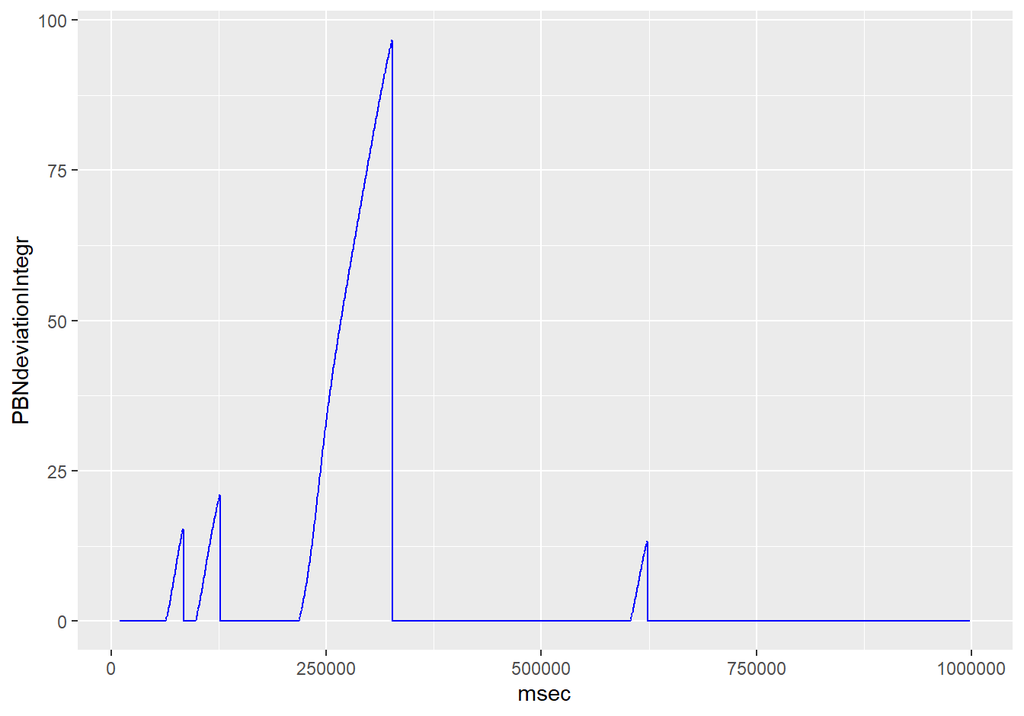

-blue: PBNdeviationIntegr

##### En la siguiente valiable se ha introducido una cota cuando el error se sitúa entre el primer y el 2º umbral (en este caso el valor es un poco arbitrario, 10).

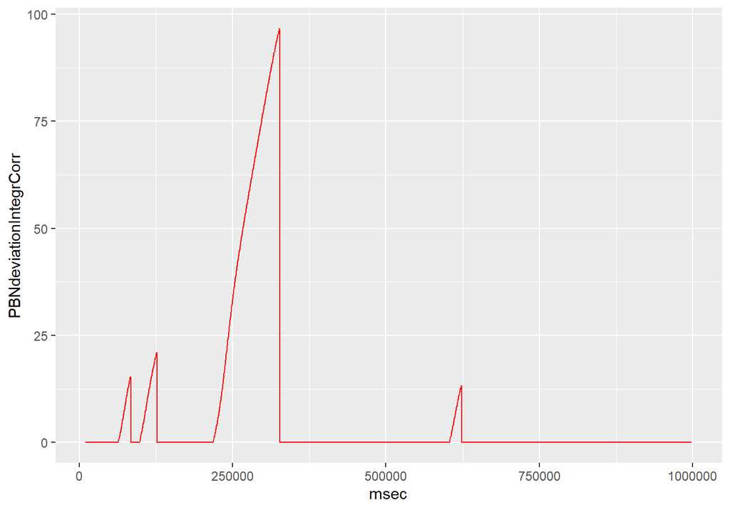

-red: PBNdeviationIntegrCorr

#### Versión discretizada dscrPBNdeviationIntegrCorr:

- 0: El error es pequeño o lleva mu poco tiempo cometiéndose.
- 1: Puede que lleve más tiempo cometiéndose, pero el error es pequeño <0.8.
- 2: El error ya ha alcanzado 0.8, pero todavía su integral no es excesiva.
- 3: El error ya ha alcanzado 0.8, y su integral sí es excesiva.

##### En la siguiente valiable se ha introducido una cota cuando el error se sitúa entre el primer y el 2º umbral (en este caso el valor es un poco arbitrario, 10).

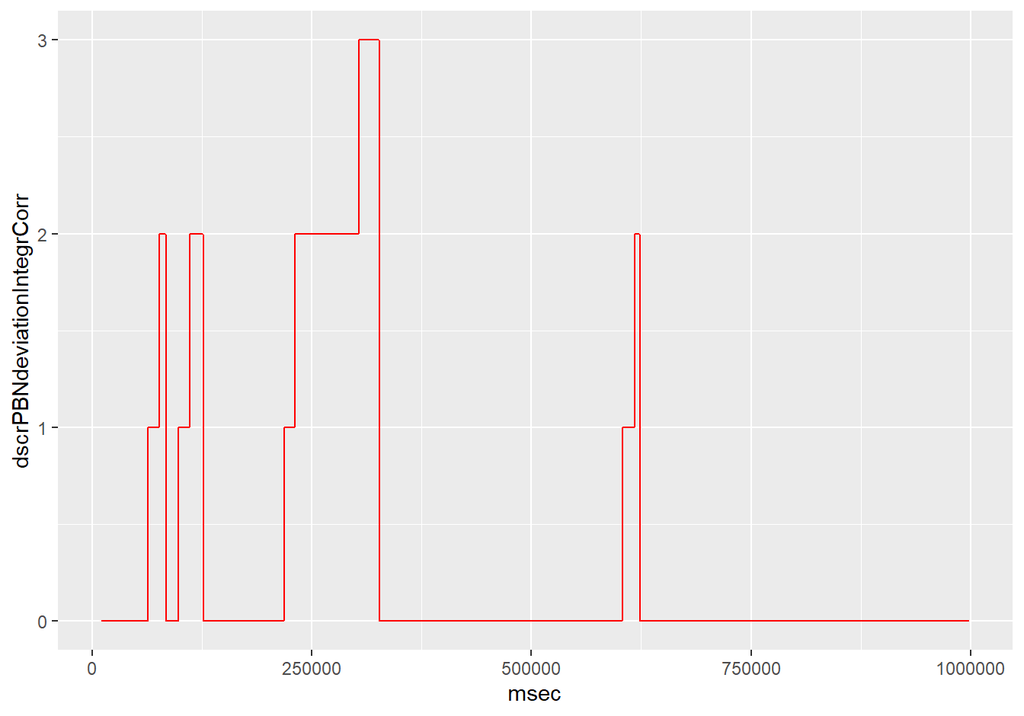

-red: dscrPBNdeviationIntegrCorr